# Introduction

First we need to save data frame as **.csv** file in R  
I called my folder “Mitch Regression Presentation”  
Click that foler and “set as working directory”

Make sure you don’t set the “data” folder as the working directory!

Then

```r
nomoreg <- read.csv("data/MultipleLinearRegression.csv")
head(nomoreg)
```

```
##   Decibels Average.Minimum.Frequency Average.Maximum.Frequency
## 1     48.5                  2315.364                  4359.528
## 2     49.2                  2143.151                  3980.353
## 3     47.6                  1947.255                  4035.504
## 4     45.1                  2083.373                  4117.213
## 5     43.8                  2004.832                  3816.045
## 6     46.9                  2031.311                  4102.632
##   Average.Peak.Frequency
## 1               3072.417
## 2               2860.636
## 3               2931.759
## 4               2923.729
## 5               2910.571
## 6               2764.603
```

Now you can see what the data frame looks like straight from the **.csv** file  
However, this is not R friendly for ggplot  
We need to do something MORE involving the *melt* function

# “Melting” Your Data Set

First thing is to go into the console and type **?mark.data.frame**  
The key “argument” here is *id.vars* , which is a vector of id variables  
Create a new heading using the melt function  
BUT FIRST!! We have to open the “reshape2” package  
THEN we can create the “melted” data set

```r
library(reshape2)
nomoregmelt <- melt(nomoreg,id.vars="Decibels")
head(nomoregmelt)
```

```
##   Decibels                  variable    value
## 1     48.5 Average.Minimum.Frequency 2315.364
## 2     49.2 Average.Minimum.Frequency 2143.151
## 3     47.6 Average.Minimum.Frequency 1947.255
## 4     45.1 Average.Minimum.Frequency 2083.373
## 5     43.8 Average.Minimum.Frequency 2004.832
## 6     46.9 Average.Minimum.Frequency 2031.311
```

So now you see i’ve created 3 columns:  
- Decibels (my x value)  
- variable (titled average minimum, average maximum, or average peak frequency)  
- value (the actual frequency values)

Too see the entire data set now you just need to “view” nomoregmelt

# Making the Graph

First open ggplot 2

```r
library(ggplot2)
```

Then we create **regression graph 1**

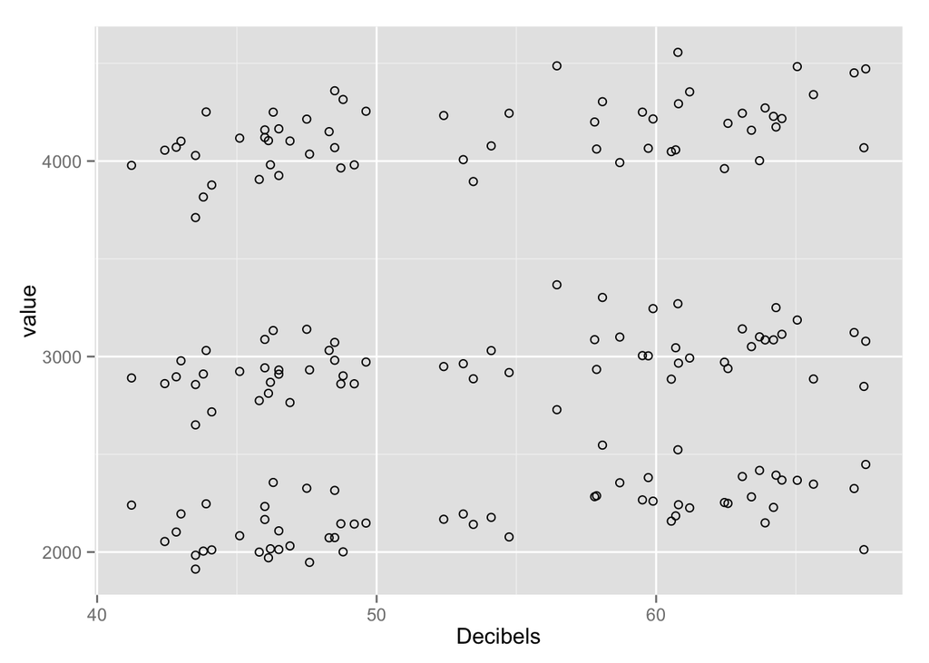

```r
ggplot(nomoregmelt, aes(x=Decibels, y= value))+
  geom_point(shape=1)
```

Here i told r that our x values represent “Decibels”  
and that our y is the numbers from the “value” column in the melted data frame

So now we’ve got all three sets of y values placed under one x value (Decibels)

However, this is ugly, real ugly  
- Which set of data represents average peak frequency?  
- What do the points even mean?!  
- Wait, what does “value” mean??!  
- WHAT DOES ANY OF THIS MEAN???

Calm down people, everything will be, just fine…

Well, first thing we can do is change the color and shape of the points  
and then indicate which set of points represents which set of data

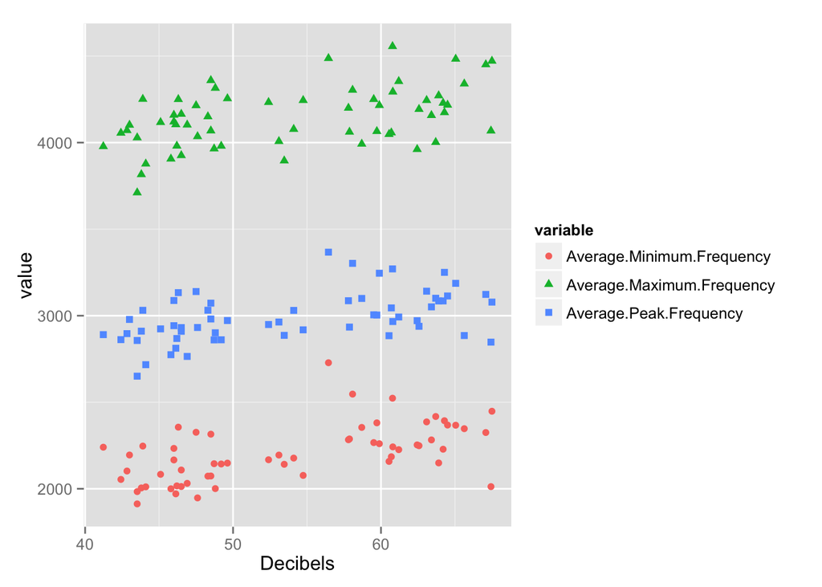

```r
ggplot(nomoregmelt, aes(x=Decibels, y= value, colour=variable, shape=variable))+
  geom_point()
```

Ok, well this certainly an improvement

Now we’ve told R to make the color and shapes of the “variable” values different  
Remember that’s why we made three columns from the “melted” data frame  
- Decibels = x values  
- value = frequency values, aka y values  
- variable = average minimum, maximum, and peak frequency

Now the color and shape of the points are connected to “variable”  
You might also noticed that all these changes are in the first row of the ggplot script  
- “geom_point()” has nothing in the parenthesis

If we put something in the geom_point() then we get something like…

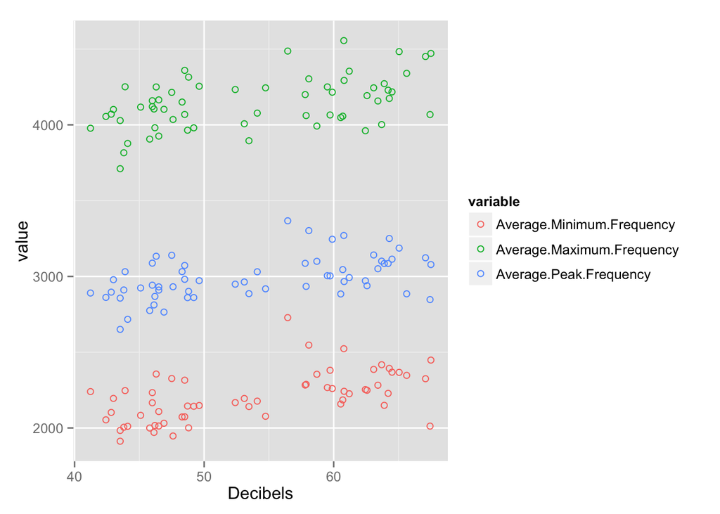

```r
ggplot(nomoregmelt, aes(x=Decibels, y= value, colour=variable, shape=variable))+
  geom_point(shape=1)
```

ok back to the RIGHT way

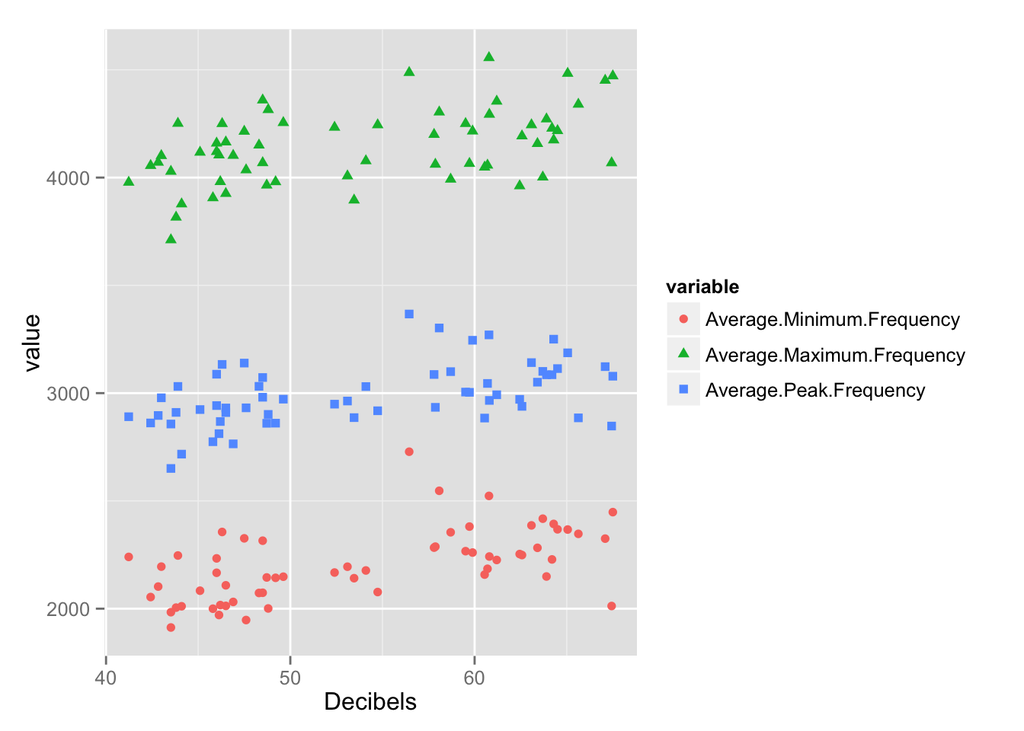

```r
ggplot(nomoregmelt, aes(x=Decibels, y= value, colour=variable, shape=variable))+
  geom_point()
```

Now we need to change the name of “value” and “variable” to something that’s less vague

To do this we have to back to the original “nomoregmelt” script and change it  
We introduce two new arguments from **?mark.data.frame**  
- value.name  
- variable.name

```r
nomoregmelt <- melt(nomoreg, id.vars="Decibels", value.name="Average Frequency", variable.name="Frequency")
```

now we plug these new values back into the ggplot script from before  
WHAT? value and variable are evolving!…

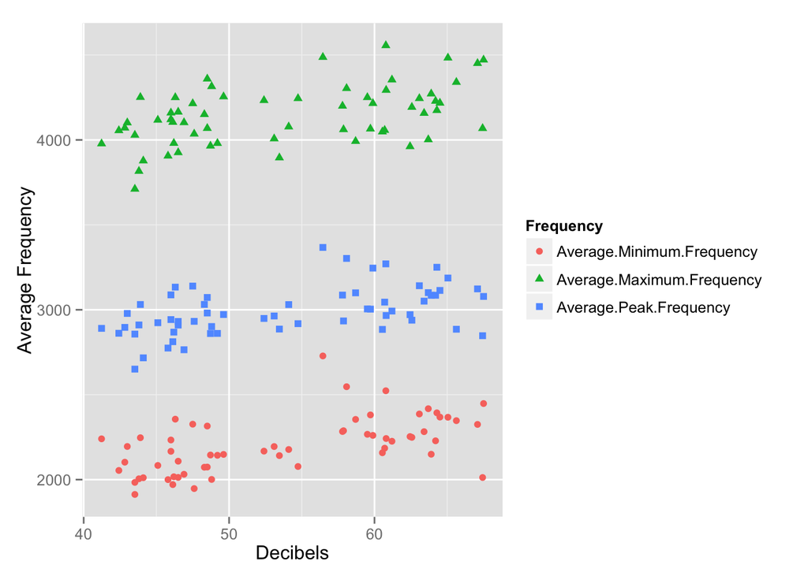

```r
ggplot(nomoregmelt, aes(x=Decibels, y= `Average Frequency`, colour=Frequency, shape=Frequency))+ geom_point()
```

value has evolved into Average Frequency and  
variable has evolved into Frequency! Thus ends the pokemon reference

And thus ends my terrible pokemon reference

But there are few more things i’d like to do, like add trendlines

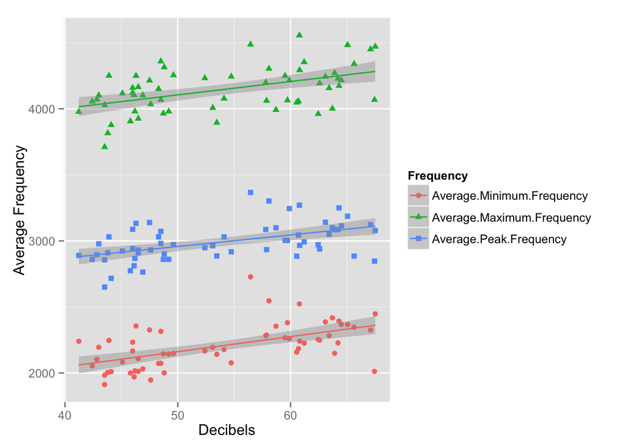

```r
ggplot(nomoregmelt, aes(x=Decibels, y= `Average Frequency`, colour=Frequency, shape=Frequency))+
  geom_point()+
  geom_smooth(method=lm)
```

And last, let’s get rid of that grey background and gridlines

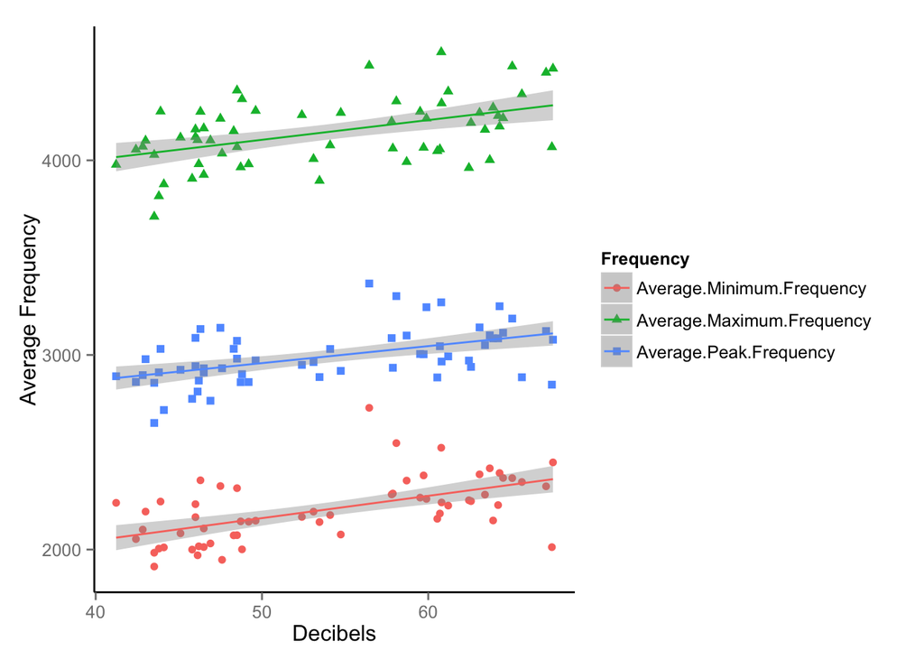

```r
ggplot(nomoregmelt, aes(x=Decibels, y= `Average Frequency`, colour=Frequency, shape=Frequency))+
  geom_point()+
  geom_smooth(method=lm)+
  theme(panel.grid.major = element_blank(), panel.grid.minor = element_blank(),
  panel.background = element_blank(), axis.line = element_line(colour = "black"))
```

And there you have it?

But there are still a couple of things wrong this graph…  
Things i do NOT know how to change…

- First, how to take the periods away from the frequency titles
- Second, how to get rid of “frequency” title and make a proper legend

How would you guys do this??